# Exercise Accuracy Prediction

Sarthak

30/09/2020

## 1. Overview

The goal of this project is to predict the manner in which an exercise is performed, especially barbell lifts. A group of 6 participants was asked to perform this exercise correctly and incorrectly in five different ways. Data was collected from accelerometers connected on the belt, forearm, arm and dumbbell of these participants.

**Loading required R packages**

```r
# removing any previous variables present in the global environment
rm(list = ls())

# loading required packages
library(caret)
library(rpart)
library(rpart.plot)
library(rattle)
library(randomForest)
library(corrplot)

# setting the seed, for reproducibility
set.seed(13232)
```

## 2. Exporatory Data Analysis

### a) Data Loading and Partitioning

```r
# loading the training data set
trainDataset <- read.csv(url("http://d396qusza40orc.cloudfront.net/predmachlearn/pml-training.csv"))

# loading the testing data set
testingDataSet <- read.csv(url("http://d396qusza40orc.cloudfront.net/predmachlearn/pml-testing.csv"))

# partitioning the training set into training and validation sets
trainInd <- createDataPartition(y = trainDataset$classe, p = 0.7, list = FALSE)
# here, "classe" is the output variable classifying the manner of doing an exercise into different classes
trainSubset <- trainDataset[trainInd,]
validSubset <- trainDataset[-trainInd,]
```

```r
# dimensions of training sub set
dim(trainSubset)
```

```
## [1] 13737   160
```

```r
# dimensions of validation sub set
dim(validSubset)
```

```
## [1] 5885  160
```

### b) Cleaning the Data

```r
# variable names in the data set
colnames(trainSubset)
```

```
##   [1] "X"                        "user_name"
##   [3] "raw_timestamp_part_1"     "raw_timestamp_part_2"
##   [5] "cvtd_timestamp"           "new_window"
##   [7] "num_window"               "roll_belt"
##   [9] "pitch_belt"               "yaw_belt"
##  [11] "total_accel_belt"         "kurtosis_roll_belt"
##  [13] "kurtosis_picth_belt"      "kurtosis_yaw_belt"
##  [15] "skewness_roll_belt"       "skewness_roll_belt.1"
##  [17] "skewness_yaw_belt"        "max_roll_belt"
##  [19] "max_picth_belt"           "max_yaw_belt"
##  [21] "min_roll_belt"            "min_pitch_belt"
##  [23] "min_yaw_belt"             "amplitude_roll_belt"
##  [25] "amplitude_pitch_belt"     "amplitude_yaw_belt"
##  [27] "var_total_accel_belt"     "avg_roll_belt"
##  [29] "stddev_roll_belt"         "var_roll_belt"
```

[output cut: 65 more lines]

```r
# description of the output variable
str(trainSubset$classe)
```

```
##  chr [1:13737] "A" "A" "A" "A" "A" "A" "A" "A" "A" "A" "A" "A" "A" "A" "A" ...
```

As we can see, the output variable comprises of classification of the activites into various classes. So, it would be better to convert it into a factor variable

```r
# converting the output variable into a factor variable
trainSubset$classe <- as.factor(trainSubset$classe)
validSubset$classe <- as.factor(validSubset$classe)

# new description for the output variable
str(trainSubset$classe)
```

```
##  Factor w/ 5 levels "A","B","C","D",..: 1 1 1 1 1 1 1 1 1 1 ...
```

The first five variables in the data set are identification variables, and are not necessary for prediction purposes. So, those variables can be removed.

```r
# removing the identification variables
trainSubset <- trainSubset[, -(1:5)]
validSubset <- validSubset[, -(1:5)]
```

Some variables may also have negligible variablility, such that including only one of them in the data set will not help in explaining any observed variability in the outcome. We will remove such variables.

```r
# looking for variables with zero variability
zeroVarVariables <- nearZeroVar(trainSubset)
trainSubset <- trainSubset[, -zeroVarVariables]
validSubset <- validSubset[, -zeroVarVariables]
```

Some variables might also have a lot NA or Null values, which will create a lot of problems while training models on this data set. We will remove these variables

```r
# finding variables that have a lot of NAs and removing them
avgNA <- sapply(trainSubset, function(x) mean(is.na(x))) > 0.95
trainSubset <- trainSubset[, avgNA == F]
validSubset <- validSubset[, avgNA == F]
```

```r
# Final dimensions of the training subset
dim(trainSubset)
```

```
## [1] 13737    54
```

```r
# Final dimensions of the validation subset
dim(validSubset)
```

```
## [1] 5885   54
```

### c) Correlation Analysis

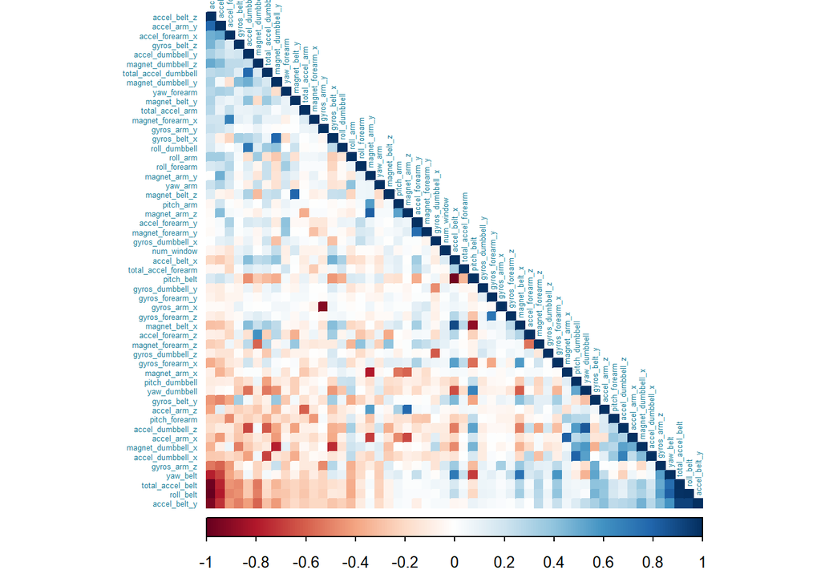

```r
# Creating a correlation matrix between all variables (excluding the output variable)
correlateMat <- cor(trainSubset[, -54])
corrplot(correlateMat, order = "FPC", method = "color", type = "lower",
         tl.cex = 0.4, tl.col = rgb(0.1, 0.5, 0.6))
```

The variables along the diagonal are the same as the ones in the vertical axis, so they will have the highest correlation of 1 (marked with the darkest hue of blue/violet).

The darker the colors in a square in the plot, the more correlated are the variables corresponding to that square. Since, there are low numbers of highly correlated variables, so no principal component analysis has to be performed to further reduce the number of variables in the data set.

## 2. Comparing Prediction Models

Three prediction models will be trained on the training subset, and will be used for predicting the outcomes on the validation subset. The model having the highest classification accuracy will be selected for predicting the outcomes of the testing data set.

### a) Decision Tree

```r
# training the classification tree model on the training subset
set.seed(13232)
modelFitdt <- rpart(classe ~ ., data = trainSubset, method = "class")
```

```r
# creating predictions on the validation data set
predictdt <- predict(modelFitdt, newdata = validSubset, type = "class")

# creating a confusion matrix for showing the prediction accuracy
# this will also show the prediction accuracy, some other stats,
# and a some error values for the different classes in the output
confusionMatdt <- confusionMatrix(predictdt, validSubset$classe)
confusionMatdt
```

```
## Confusion Matrix and Statistics
##
##           Reference
## Prediction    A    B    C    D    E
##          A 1419  148   17   49   57
##          B   63  660   77   78  117
##          C   24   66  755  154   95
##          D  150  227  147  635  125
##          E   18   38   30   48  688
##
## Overall Statistics
##
##                Accuracy : 0.7064
##                  95% CI : (0.6946, 0.718)
##     No Information Rate : 0.2845
##     P-Value [Acc > NIR] : < 2.2e-16
##
##                   Kappa : 0.6291
##
##  Mcnemar's Test P-Value : < 2.2e-16
##
## Statistics by Class:
##
##                      Class: A Class: B Class: C Class: D Class: E
## Sensitivity            0.8477   0.5795   0.7359   0.6587   0.6359
## Specificity            0.9356   0.9294   0.9302   0.8681   0.9721
## Pos Pred Value         0.8396   0.6633   0.6901   0.4945   0.8370
## Neg Pred Value         0.9392   0.9020   0.9434   0.9285   0.9222
## Prevalence             0.2845   0.1935   0.1743   0.1638   0.1839
## Detection Rate         0.2411   0.1121   0.1283   0.1079   0.1169
## Detection Prevalence   0.2872   0.1691   0.1859   0.2182   0.1397
## Balanced Accuracy      0.8917   0.7544   0.8331   0.7634   0.8040
```

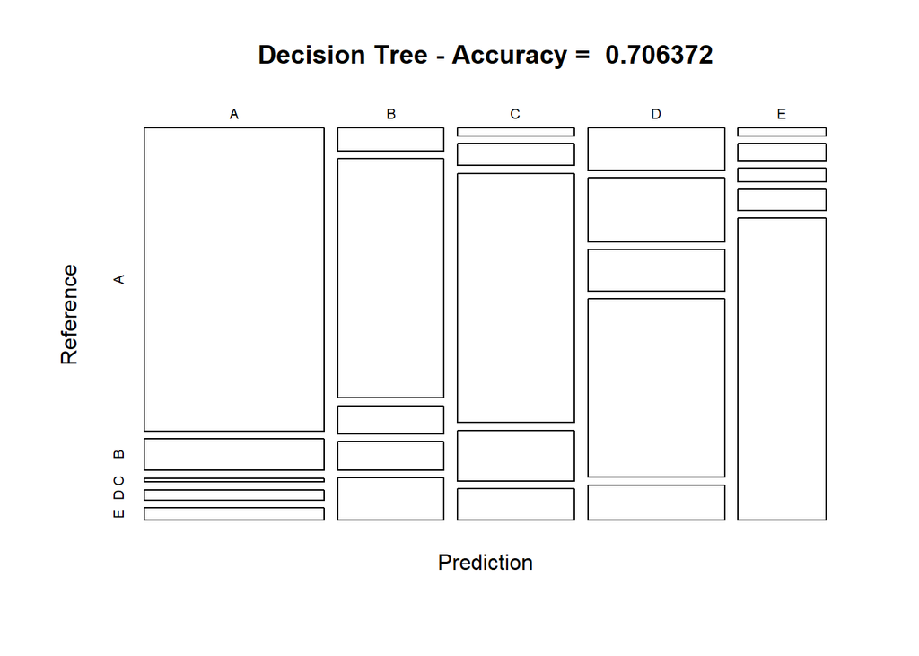

```r
# plotting the values in the confusion matrix
plot(confusionMatdt$table, col = confusionMatdt$byClass,
     main = paste("Decision Tree - Accuracy = ", round(confusionMatdt$overall['Accuracy'], 6)))
```

The number of correct classification of classes can be seen in the left diagonal of the confusion matrix.

### b) Random Forest

```r
# training the random forest model on the training subset
set.seed(13232)

# performing cross-validation on the training subset
rfcv <- trainControl(method = "cv", number = 3, verboseIter = F)

modFitrf <- train(classe ~ ., data = trainSubset, method = "rf", trControl = rfcv)
modFitrf$finalModel
```

```
##
## Call:
##  randomForest(x = x, y = y, mtry = param$mtry)
##                Type of random forest: classification
##                      Number of trees: 500
## No. of variables tried at each split: 27
##
##         OOB estimate of  error rate: 0.25%
## Confusion matrix:
##      A    B    C    D    E class.error
## A 3906    0    0    0    0 0.000000000
## B    8 2647    3    0    0 0.004138450
## C    0    4 2392    0    0 0.001669449
## D    0    0   12 2240    0 0.005328597
## E    0    1    0    6 2518 0.002772277
```

```r
# creating predictions on the validation data set
predictrf <- predict(modFitrf, newdata = validSubset)

# creating a confusion matrix for showing the prediction accuracy
# this will also show the prediction accuracy, some other stats,
# and a some error values for the different classes in the output
confusionMatrf <- confusionMatrix(predictrf, validSubset$classe)
confusionMatrf
```

```
## Confusion Matrix and Statistics
##
##           Reference
## Prediction    A    B    C    D    E
##          A 1672    2    0    0    0
##          B    1 1137    1    0    0
##          C    0    0 1025   12    0
##          D    0    0    0  952    1
##          E    1    0    0    0 1081
##
## Overall Statistics
##
##                Accuracy : 0.9969
##                  95% CI : (0.9952, 0.9982)
##     No Information Rate : 0.2845
##     P-Value [Acc > NIR] : < 2.2e-16
##
##                   Kappa : 0.9961
##
##  Mcnemar's Test P-Value : NA
##
## Statistics by Class:
##
##                      Class: A Class: B Class: C Class: D Class: E
## Sensitivity            0.9988   0.9982   0.9990   0.9876   0.9991
## Specificity            0.9995   0.9996   0.9975   0.9998   0.9998
## Pos Pred Value         0.9988   0.9982   0.9884   0.9990   0.9991
## Neg Pred Value         0.9995   0.9996   0.9998   0.9976   0.9998
## Prevalence             0.2845   0.1935   0.1743   0.1638   0.1839
## Detection Rate         0.2841   0.1932   0.1742   0.1618   0.1837
## Detection Prevalence   0.2845   0.1935   0.1762   0.1619   0.1839
## Balanced Accuracy      0.9992   0.9989   0.9983   0.9937   0.9994
```

[figure not shown]

```r
# plotting the values in the confusion matrix
plot(confusionMatrf$table, col = confusionMatrf$byClass,
     main = paste("Decision Tree - Accuracy = ", round(confusionMatrf$overall['Accuracy'], 6)))
```

### c) Generalized Boosting Model

```r
# training the generalized boosting model on the training subset
set.seed(13232)

# performing cross-validation on the training subset
gbmcv <- trainControl(method = "cv", number = 3)

modFitgbm <- train(classe ~ ., data = trainSubset, method = "gbm", trControl = gbmcv, verbose = F)
modFitgbm$finalModel
```

```
## A gradient boosted model with multinomial loss function.
## 150 iterations were performed.
## There were 53 predictors of which 53 had non-zero influence.
```

```r
# creating predictions on the validation data set
predictgbm <- predict(modFitgbm, newdata = validSubset)

# creating a confusion matrix for showing the prediction accuracy
# this will also show the prediction accuracy, some other stats,
# and a some error values for the different classes in the output
confusionMatgbm <- confusionMatrix(predictgbm, validSubset$classe)
confusionMatgbm
```

```
## Confusion Matrix and Statistics
##
##           Reference
## Prediction    A    B    C    D    E
##          A 1673   17    0    0    0
##          B    1 1110    7    1    3
##          C    0    7 1017   12    1
##          D    0    5    2  950    8
##          E    0    0    0    1 1070
##
## Overall Statistics
##
##                Accuracy : 0.989
##                  95% CI : (0.9859, 0.9915)
##     No Information Rate : 0.2845
##     P-Value [Acc > NIR] : < 2.2e-16
##
##                   Kappa : 0.986
##
##  Mcnemar's Test P-Value : NA
##
## Statistics by Class:
##
##                      Class: A Class: B Class: C Class: D Class: E
## Sensitivity            0.9994   0.9745   0.9912   0.9855   0.9889
## Specificity            0.9960   0.9975   0.9959   0.9970   0.9998
## Pos Pred Value         0.9899   0.9893   0.9807   0.9845   0.9991
## Neg Pred Value         0.9998   0.9939   0.9981   0.9972   0.9975
## Prevalence             0.2845   0.1935   0.1743   0.1638   0.1839
## Detection Rate         0.2843   0.1886   0.1728   0.1614   0.1818
## Detection Prevalence   0.2872   0.1907   0.1762   0.1640   0.1820
## Balanced Accuracy      0.9977   0.9860   0.9936   0.9912   0.9944
```

[figure not shown]

```r
# plotting the values in the confusion matrix
plot(confusionMatgbm$table, col = confusionMatgbm$byClass,
     main = paste("Decision Tree - Accuracy = ", round(confusionMatgbm$overall['Accuracy'], 6)))
```

## 3. Predicting Values from the Test Data

The 3 models shown above have the following accuracy values:

1. Decision Tree: 0.706372
2. Random Forest: 0.996941
3. Generalized Boosting Model: 0.988955

From the accuracy values, it can be said that the Random Forest model is the most accurate. So, that will be used to predict the final test data set values.